# Generative Art

Author

Nick Soares

# Gallery Entry #1

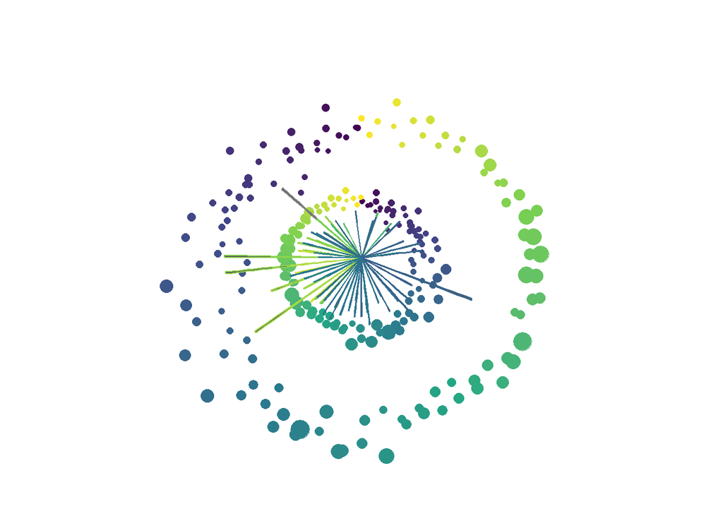

```r
#using a phytoplankton monitoring time series from Morro Bay

hab <- read.csv("data/MBF_upload.csv")

#modifying and overlaying data on a single plot

hab_spiral <- hab |>
  ggplot() +
  geom_point(aes(Day.of.Year..1.365.,
             log10(Total.Phytoplankton..cells.L.),
             colour = Day.of.Year..1.365.,
             size = Avg.Chloro..mg.m3./2),
             show.legend = FALSE) +
  geom_point(aes(abs(366-Day.of.Year..1.365.),
             log(Total.Phytoplankton..cells.L.),
             colour = Day.of.Year..1.365.,
             size = Avg.Chloro..mg.m3.),
             show.legend = FALSE) +
  geom_bar(aes(Day.of.Year..1.365.,
              log10(Akashiwo.sanguinea..cells.L.),
              colour  = Temp..deg.C.*20),
           stat = "identity",
           show.legend = FALSE) +
  geom_bar(aes(Day.of.Year..1.365.,
              log10(Pseudo.nitzschia.seriata.group..cells.L.),
              colour  = Temp..deg.C.*10),
           stat = "identity",
           show.legend = FALSE) +
  coord_polar() +
  theme_void() +
  scale_color_viridis_c()

hab_spiral
```

## Title: GalaxSea

### Dramatic Description

When viewed under a microscope, the phytoplankton that inhabit the ocean can appear as numerous as the stars in the sky. This piece uses a plankton monitoring time series as the underlying dataset, from which transformations, aesthetic manipulations, and layering result in a swirling assortment of points and rays akin to a solar system. This piece evokes the continuum between microscopic and macroscopic, the inherent link between the smallest and largest scales accessible to human observation.

### Code Choices

Using `coord_polar()` changes the structure of the x-axis so all the data spirals around a central point. Multiple data transformations (such as log scaling) are used in the layered `geom_bar()` and `geom_point()` calls to space out the data so it has a characteristic cosmic feel, like asteroid belts encircling the sun.

# Gallery Entry #2

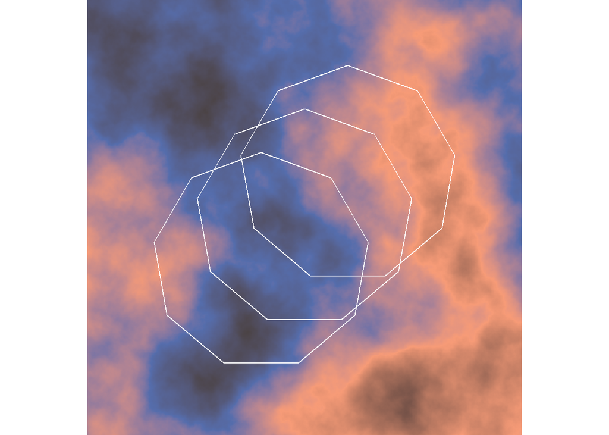

```r
#generate color palettes

sample_canva <- function(seed = NULL) {
  if(!is.null(seed)) set.seed(seed)
  sample(ggthemes::canva_palettes, 1)[[1]]
}

#create a canvas

x_coords <- seq(from = 0, to = 1, length.out = 800)
y_coords <- seq(from = 0, to = 1, length.out = 800)
canvas <- long_grid(x = x_coords, y = y_coords)

#add some generated "paint" to the canvas

canvas <- canvas |>
  mutate(paint = fracture(
            noise = gen_simplex,
            x = x,
            y = y,
            octaves = 20,
            fractal = fbm,
            seed = 29))

#defining the shape of a nonagon to add some structure/geometry to the fractal chaos

theta <- (0:9) * pi / 4.5
nonagon <- tibble(
  x = sin(theta),
  y = cos(theta)
)

nonagon_scale <- nonagon |>
  mutate(x_scale = x/4+0.5,
         y_scale = y/4+0.5)

#putting them all together

fractal_plot <- ggplot() +
  geom_raster(data = canvas,
              aes(x, y, fill = paint),
              show.legend = FALSE) +
  scale_x_continuous(expand = c(0, 0)) +
  scale_y_continuous(expand = c(0, 0)) +
  scale_fill_gradientn(colours = sample_canva(seed = 42)) +
  geom_polygon(data = nonagon_scale,
               aes(x_scale, y_scale),
               colour = "white",
               fill = NA,
               show.legend = FALSE) +
  geom_polygon(data = nonagon_scale,
               aes(x_scale-0.1, y_scale-0.1),
               colour = "white",
               fill = NA,
               show.legend = FALSE) +
  geom_polygon(data = nonagon_scale,
               aes(x_scale+0.1, y_scale+0.1),
               colour = "white",
               fill = NA,
               show.legend = FALSE) +
  coord_equal() +
  theme_void()

fractal_plot
```

## Title: Nebulagon

### Dramatic Description

A nebula at the outskirts of a distant galaxy. Within the gas and cosmic dust, a set of rings stand out, their seemingly-purposeful angularity denoting intelligent design amidst chaos. Perhaps leftover structures from an ancient, insterstellar race? Do you dare approach?

### Code Choices

The `sample_canva()` function generates a random palette that is replicable if we set a “seed”. The `fracture()` function used when “painting the canvas” takes the noise generated using `gen_simplex()` and repeatedly applies it at different frequencies. By setting “octaves” to 20, the generator and fractal functions iterate over the algorithm 20 times. The nonagon structure is first built as a tibble, then rescaled using some simple transformations so it appears at the center of the final plot. The final image brings all elements together by layering polygons on top of a raster base.